# Analysis of MPs Expenses

### Percentage

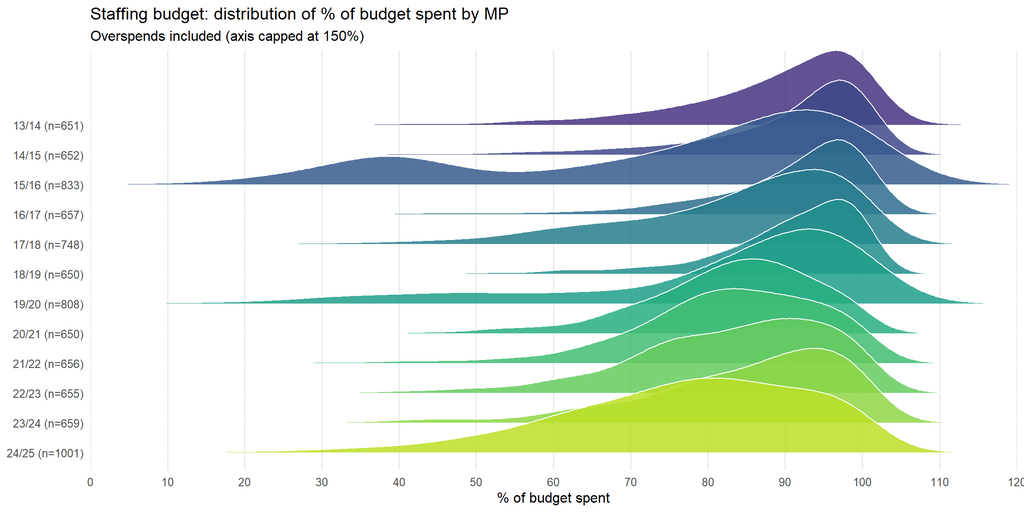

*Figure 3**: Density plot of the percentage of budget spent by each MP over time. Note that a series of outliers are present where over 100% of the budget is spent.*

### Overspend

*Table 1**: All instances of budgetary overspend in any category.*

| MP | Constituency | Financial year | Budget type | Budget | Spend | Remaining budget | Overspend | % spent |
| --- | --- | --- | --- | --- | --- | --- | --- | --- |
| David Ruffley | Bury St Edmunds CC | 13/14 | Staffing | 139900 | 167799.63 | -27899.63201415 | 27899.63201415 | 119.9425518227305 |
| Danny Alexander | Inverness, Nairn, Badenoch and Strathspey CC | 13/14 | Staffing | 137200 | 157083.38 | -19883.38201415 | 19883.38201415 | 114.4922594752187 |
| Paul Maynard | Blackpool North and Cleveleys BC | 13/14 | Staffing | 137200 | 147940.11 | -10740.11201415 | 10740.11201415 | 107.8280685131195 |
| Ian Paisley | North Antrim CC | 14/15 | Office | 16617.32 | 25723.5 | -9106.18 | 9106.18 | 154.7993298558372 |
| Gerald Kaufman | Manchester, Gorton BC | 17/18 | Winding-up | 77818.01 | 86478.07 | -8660.06 | 8660.06 | 111.1286063470397 |
| Karen Buck | Westminster North BC | 13/14 | Staffing | 148066.83 | 156177.15 | -8110.32201415 | 8110.32201415 | 105.4774725710005 |
| Debbie Abrahams | Oldham East and Saddleworth CC | 14/15 | Staffing | 138600 | 146302.98 | -7702.98 | 7702.98 | 105.5577056277056 |
| Tracey Crouch | Chatham and Aylesford CC | 19/20 | Staffing | 155930 | 163625.83 | -7695.83 | 7695.83 | 104.935438979029 |
| Tessa Munt | Wells CC | 13/14 | Staffing | 137200 | 143737.28 | -6537.28 | 6537.28 | 104.7647813411079 |
| David Morris | Morecambe and Lunesdale CC | 13/14 | Office | 22750 | 29151.38 | -6401.38201415 | 6401.38201415 | 128.1379340659341 |

[output cut: 229 more lines]

Several conclusions can be made on the above visualisations:

- Despite `Staffing` spend increasing, the amount of under spend against budget is also increasing suggesting continuous over-estimation of spend year on year.
- There a potential up-tick in over-estimation in recent years for `Office` and `Accommodation` expenses, however, more data would be required to draw a firm conclusion.
- There is an interesting feature in FY 15/16 where a significant proportion of constituencies only spent ~30-40% of their budget. This should be investigated further to confirm validity.

# Further Areas of Inquiry

This analysis provides a few areas that warrant further investigation:

- Confirmation that overspend data is accurate and not due to data quality issues.
- Understanding of what is driving the rapid increase in `Staffing` spend and budget despite a trend of under spend appearing since budgets have increased.
- Trend analysis of whether specific constituencies are likely to over or under spend on certain areas.
- Data quality review to confirm if the outliers of ~30% budget spend in FY 15/16 are valid.